# Logistic regression 1

STA 235 Week 9

Emre Yucel

University of Texas at Austin

2026-10-21

# The basic logistic regression model

## The LendingClub data set

- The LendingClub data set contains information about 96736 funded loans for home improvement, debt consolidation, or small business purposes.
- We have data on each borrower’s credit sub-grade, loan amount, interest rate, income, and more. We also know whether each loan was **fully paid** or **charged off** (defaulted).
- Let’s see if we can predict whether a loan will be fully paid based on the borrower’s **credit score** (a 0–100 scale derived from LendingClub’s sub-grade system).

## What’s wrong with this regression?

$$\begin{align*}
\text{fully.paid} = \hat{\beta_0} + \hat\beta_1\cdot\text{credit\_score}
\end{align*}$$

The $Y$ variable here is categorical (two levels—a loan is either fully paid or it isn’t), so regular linear regression won’t work here.

## The idea behind logistic regression

- Instead of predicting whether a loan is fully paid, let’s predict the *probability* that it is fully paid.
- In logistic regression, one level of $Y$ is always called “success” and the other “failure.” Since $Y=1$ for fully paid loans, we designate **fully paid** as “success.”
- Logistic regression predicts the probability of success $p$ as a function of $X$ indirectly, by modeling the *log-odds* of success as a linear function of $X$.

## Odds

- When something has “even (1/1) odds,” the probability of success is $1/2$
- When something has “2/1 odds,” the probability of success is $2/3$
- When something has “3/2 odds,” the probability of success is $3/5$
- In general, the odds of something happening are $p/(1-p)$
- …and so the probability of something happening is $\text{odds}/(1+\text{odds})$

## Odds

Before Texas played Gonzaga in the 2026 NCAA Tournament Second Round, DraftKings listed Texas at **+200**—meaning a $100 bet on Texas winning would pay out $200.

That is, they were giving Texas odds to *win* of $\$100/\$200 = 1/2$ (ignoring house edge).

What’s their implied *probability* that Texas would win?

$$\frac{p}{1-p} = \frac{1}{2} \Rightarrow p = \frac{1/2}{1+1/2} \approx 0.333$$

## Odds

Before Texas played Purdue in the 2026 NCAA Tournament Sweet 16, DraftKings listed Texas at **+290**—meaning a $100 bet on Texas winning would pay out $290.

That is, they were giving Texas odds to *win* of $\$100/\$290 \approx 0.345$. What’s their implied *probability* that Texas would win?

## Probability vs odds vs log odds

Odds and log odds are just different ways of expressing probabilities:

| Probability | Odds | Log odds |
| --- | --- | --- |
| $p$ | $p/(1-p)$ | $\log(p/(1-p))$ |
| Between 0 and 1 | Between 0 and $\infty$ | Between $-\infty$ and $\infty$ |
| 0 | 0 | $-\infty$ |
| 0.25 | 0.33 | $-1.10$ |
| 0.5 | 1 | 0 |
| 0.75 | 3 | 1.10 |
| 0.8 | 4 | 1.39 |
| 0.9 | 9 | 2.20 |
| 0.95 | 19 | 2.94 |
| 1 | $\infty$ | $\infty$ |

## The logistic regression model

Logistic regression predicts the log odds of success $p$ as a linear function of $X$:
$$\log\left(\frac{p}{1-p}\right) = \beta_0 + \beta_1 X$$
This fits an S-shaped curve to the data (we’ll see what it looks like shortly).

## Let’s try it

```r
# Fit logistic regression: predict P(fully paid) from credit score
model <- glm(fully.paid ~ credit_score, data = loans,
             family = binomial)
summary(model)
```

```
Call:
glm(formula = fully.paid ~ credit_score, family = binomial, data = loans)

Coefficients:
             Estimate Std. Error z value Pr(>|z|)
(Intercept)  -5.86756    0.08163   -71.9   <2e-16 ***
credit_score  0.10464    0.00123    85.2   <2e-16 ***
---
Signif. codes:  0 '***' 0.001 '**' 0.01 '*' 0.05 '.' 0.1 ' ' 1

(Dispersion parameter for binomial family taken to be 1)

    Null deviance: 107169  on 96735  degrees of freedom
Residual deviance:  99212  on 96734  degrees of freedom
AIC: 99216

Number of Fisher Scoring iterations: 4
```

## How to interpret the curve?

The regression output tells us that our prediction is
$$\begin{aligned}
\log(\text{odds}) &= \log\left(\frac{P(\text{fully paid})}{1-P(\text{fully paid})}\right) \\
&= -5.868 + 0.105 \cdot\text{credit\_score}.
\end{aligned}$$

Solving for $P(\text{fully paid})$:

$$\widehat{P(\text{fully paid})} = \frac{e^{-5.868 + 0.105 \cdot\text{credit\_score}}}{1 + e^{-5.868 + 0.105 \cdot\text{credit\_score}}}$$

## Making predictions

We can use `predict` to automate plugging into the equation:

```r
# Predict probability of full repayment for a borrower with credit_score = 65
predict(model, list(credit_score = 65), type = "response")
```

```
    1
0.718
```

$$\frac{e^{-5.868 + 0.105 \cdot 65}}{1 + e^{-5.868 + 0.105 \cdot 65}} = 0.72$$

We predict that a borrower with credit score 65 has about 72% chance of fully repaying their loan.

# Interpreting the model results

## Visualizing the model

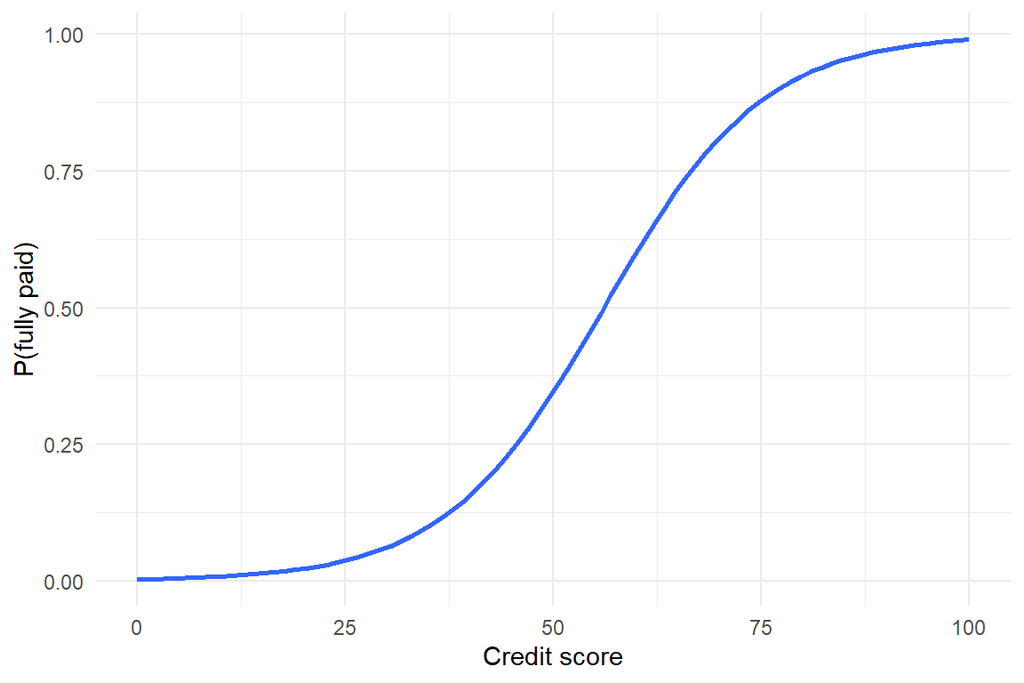

## How to interpret the curve?

$$\widehat{P(\text{fully paid})} = \frac{e^{-5.868 + 0.105 \cdot\text{credit\_score}}}{1 + e^{-5.868 + 0.105 \cdot\text{credit\_score}}}$$

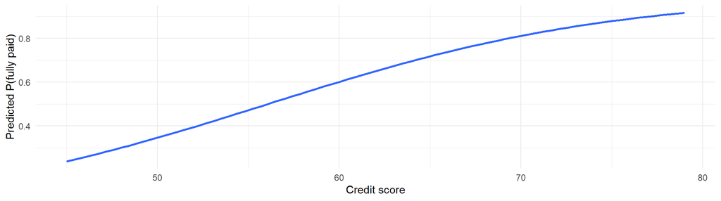

## Interpreting the coefficients

Our prediction equation is:
$$\log\left(\frac{P(\text{fully paid})}{1-P(\text{fully paid})}\right) = -5.868 + 0.105 \cdot\text{credit\_score}.$$

- We give our interepretations in odds, since log-odds are less intuitive.
- This works just like a linear regression for $\log(Y)$!

## Interpreting the coefficients

Rewriting the prediction equation as:
$$\text{Predicted odds of full repayment} = e^{-5.868 + 0.105 \cdot\text{credit\_score}}$$

- Predicted odds when credit score = 0: $e^{-5.868} = 0.003$.
- Minimum credit score in the data is 45, so not meaningful on its own here.

## Interpreting the coefficients

Rewriting the prediction equation as:
$$\text{Predicted odds of full repayment} = e^{-5.868 + 0.105 \cdot\text{credit\_score}}$$

Increasing credit score by 1 point *multiplies* the odds by $e^{0.105}=1.11$; i.e., increases the odds by $100(e^{0.105} - 1) = 11$%.

Increasing credit score by 2 points *multiplies* the odds by $e^{2 \cdot 0.105}=1.23$; i.e., increases the odds by $100(e^{2\cdot 0.105} - 1) = 23$%.

# Logistic regression with 2+ predictors

## Adding another predictor: can we do better?

- Just like with a linear regression model, we can add additional predictors to the model.
- Our interpretation of the coefficients in multiple logistic regression is similar to multiple linear regression: each coefficient represents the predicted effect of one $X$ on $Y$, holding the other $X$ variables constant.

## Does loan purpose predict repayment?

```r
# Proportion fully paid within each loan purpose
xtabs(~ purpose + fully.paid, data = loans)  %>%
  prop.table(margin = 1)  %>%
  round(2)
```

```
                    fully.paid
purpose                 0    1
  debt_consolidation 0.25 0.75
  home_improvement   0.20 0.80
  small_business     0.32 0.68
```

## Does loan purpose predict repayment?

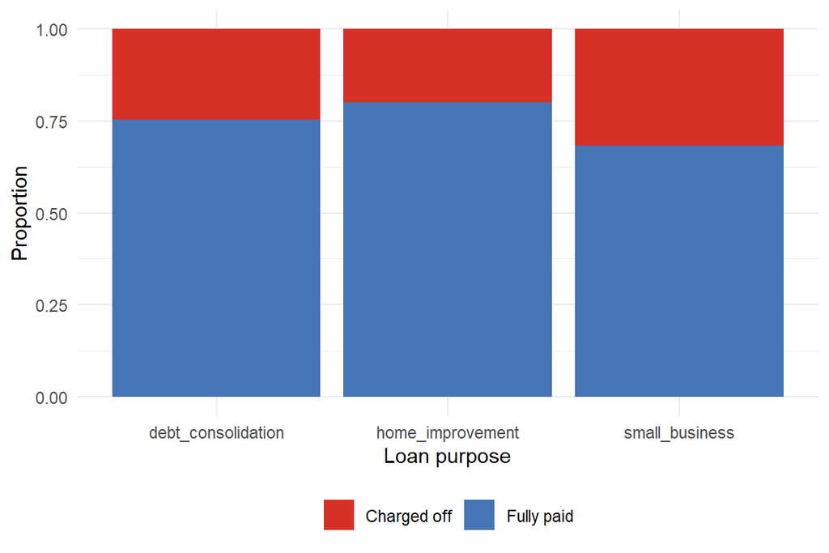

## Adding another predictor

Let’s add loan purpose as a second predictor of repayment, in addition to credit score:

```r
# Add loan purpose (reference level: debt_consolidation)
model2 <- glm(fully.paid ~ credit_score + purpose,
              data = loans, family = binomial)
```

```r
summary(model2)
```

```
Call:
glm(formula = fully.paid ~ credit_score + purpose, family = binomial,
    data = loans)

Coefficients:
                        Estimate Std. Error z value Pr(>|z|)
(Intercept)             -5.85019    0.08188  -71.45  < 2e-16 ***
credit_score             0.10419    0.00123   84.54  < 2e-16 ***
purposehome_improvement  0.13828    0.02679    5.16  2.5e-07 ***
purposesmall_business   -0.06753    0.05737   -1.18     0.24
---
Signif. codes:  0 '***' 0.001 '**' 0.01 '*' 0.05 '.' 0.1 ' ' 1

(Dispersion parameter for binomial family taken to be 1)

    Null deviance: 107169  on 96735  degrees of freedom
Residual deviance:  99183  on 96732  degrees of freedom
AIC: 99191

Number of Fisher Scoring iterations: 4
```

## Interpreting coefficients

Our prediction equation is:
$$\begin{aligned}
\log\!\left(\frac{p}{1-p}\right) &= -5.850 + 0.104 \cdot\text{credit\_score} \\
&\quad + 0.138 \cdot\text{home\_impr.} \\
&\quad - 0.068 \cdot\text{small\_bus.}
\end{aligned}$$

- For a debt consolidation loan with credit score 0, the predicted log odds are $-5.850$ (the intercept).
- Among loans with the same purpose, each additional credit score point corresponds to a 11% increase in predicted odds of full repayment (multiplied by $e^{0.104} = 1.11$).

## Interpreting coefficients

$$\begin{aligned}
\log\!\left(\frac{p}{1-p}\right) &= -5.850 + 0.104 \cdot\text{credit\_score} \\
&\quad + 0.138 \cdot\text{home\_impr.} \\
&\quad - 0.068 \cdot\text{small\_bus.}
\end{aligned}$$

- Among loans with the same credit score, home improvement loans have 15% higher predicted odds of full repayment vs. debt consolidation (multiplied by $e^{0.138} = 1.15$).
- Among loans with the same credit score, small business loans have 7% lower predicted odds of full repayment vs. debt consolidation (multiplied by $e^{-0.068} = 0.93$).

## Visualizing the model

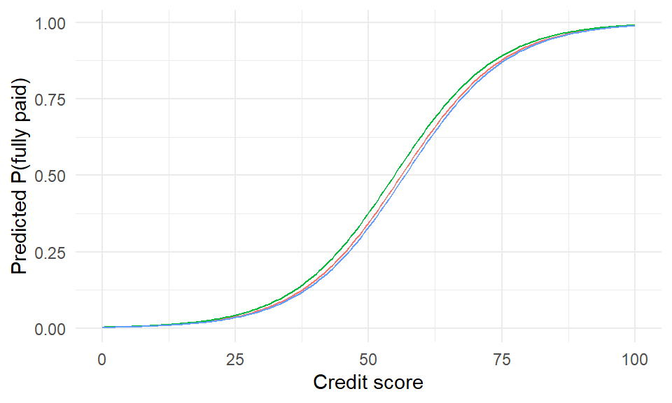

Which curve is which?

## Visualizing the model

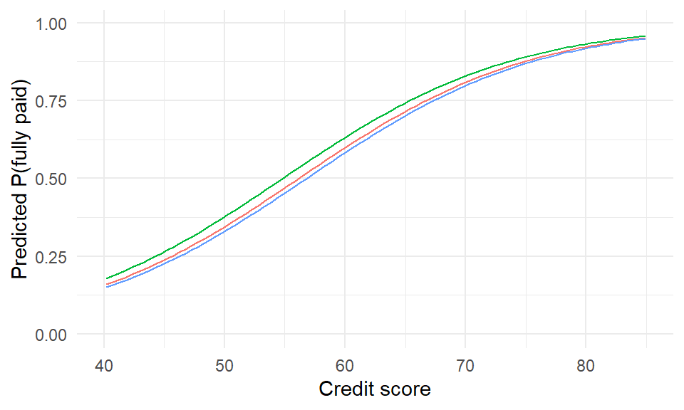

Which curve is which?

## Visualizing the model

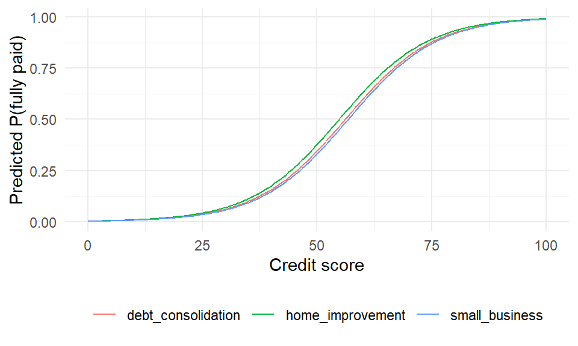

# Evaluating the model

## How good is our model?

- $R^2$ and residual standard error metrics aren’t available for logistic regression.
- There are many “pseudo-$R^2$” metrics that indicate model fit.
- But most of these are difficult to interpret, so we’ll focus on other metrics

## How many cases did we accurately predict?

We could classify each loan using a 0.5 probability threshold:

$$\text{Prediction} = \begin{cases}
\text{fully paid}, & \text{if } \widehat{P(\text{fully paid})} \geq 0.5, \\
\text{charged off}, & \text{if } \widehat{P(\text{fully paid})} < 0.5.
\end{cases}$$

```r
predicted.paid <- ifelse(
  predict(model2, type = "response") >= 0.5, 1, 0)
round(mean(predicted.paid == loans$fully.paid), 4)
```

```
[1] 0.76
```

We correctly classify 76% of the loans. Is that good?

## What should we compare that against?

What accuracy would we get if we just predicted **“fully paid” for every loan**, without using any information?

```r
# Fraction of loans that are fully paid (the "predict-everyone-pays" accuracy)
mean(loans$fully.paid)
```

```
[1] 0.758
```

A model that predicts “fully paid” for every single loan would be right **75.75%** of the time!

Our model’s accuracy: **76.02%** — a lift of 0.27 percentage points over naive. Is that good?

## Defaults are expensive!

- Overall model accuracy is similar to the baseline, but where do they make their mistakes?
  - Baseline predicts no defaults, so it gets all the fully paid loans right but all the defaults wrong.
  - Our model predicts 5549 defaults (out of 96736 total loans), of which 2904 are actually defaults
- If we had avoided writing any loans predicted to default we might have saved a lot of money!

## Reviewing a confusion matrix

|  | Actual negative | Actual positive |
| --- | --- | --- |
| Predict negative | True negative | False negative |
| Predict positive | False positive | True positive |

For example, there were **70,634 true positives**: loans we predicted would be fully paid that actually repaid in full.

```
         Actual
Predicted     0     1
        0  2904  2645
        1 20553 70634
```

Here, **positive means fully paid** ($Y=1$), and **negative means charged off** ($Y=0$).

## False positives and false negatives

In this model, **positive means fully paid** ($Y=1$), and **negative means charged off** ($Y=0$).

|  | Actual charged off ($Y=0$) | Actual fully paid ($Y=1$) |
| --- | --- | --- |
| Predict charged off | True negative | **False negative** |
| Predict fully paid | **False positive** | True positive |

- **False positive:** predict full repayment, but the borrower defaults.
- **False negative:** predict default, but the borrower repays in full.

The labels depend on which outcome we call positive.

## The confusion matrix

The **confusion matrix** compares predictions with actual outcomes.

```r
# Rows: predictions. Columns: actual outcomes.
# 0 = charged off, 1 = fully paid.
addmargins(confusion)
```

```
         Actual
Predicted     0     1   Sum
      0    2904  2645  5549
      1   20553 70634 91187
      Sum 23457 73279 96736
```

Accuracy counts the two correct cells:

$$\text{Accuracy} = \frac{\text{TN} + \text{TP}}{n}
= \frac{2904 + 70634}{96736}
= 76.02\%.$$

## False positive rate

Among loans that **actually defaulted**, what fraction did we predict would be fully paid?

$$\text{False positive rate} = \frac{\text{FP}}{\text{TN} + \text{FP}}
= \frac{20553}{23457}
= 87.62\%.$$

- These are defaults the model **missed** by predicting full repayment.
- The denominator includes **all actual defaults**, regardless of the prediction.

## False negative rate

Among loans that **actually repaid in full**, what fraction did we predict would default?

$$\text{False negative rate} = \frac{\text{FN}}{\text{FN} + \text{TP}}
= \frac{2645}{73279}
= 3.61\%.$$

- If we declined these loans, we would miss borrowers who repay in full.
- The denominator includes **all actual fully paid loans**, regardless of the prediction.

## Changing the probability cutoff

Suppose we predict full repayment only when $\widehat{P(\text{fully paid})} \geq 0.7$, instead of $0.5$.

```r
predicted.paid.70 <- ifelse(
  predict(model2, type = "response") >= 0.7, 1, 0)
table(Predicted = predicted.paid.70,
      Actual = loans$fully.paid) %>% addmargins()
```

```
         Actual
Predicted     0     1   Sum
      0   10011 14215 24226
      1   13446 59064 72510
      Sum 23457 73279 96736
```

We now require a higher predicted probability before classifying a loan as fully paid. What happens to each kind of error?

## Comparing the two cutoffs

|  | Cutoff 0.5 | Cutoff 0.7 |
| --- | --- | --- |
| False positives | 20553 | 13446 |
| False positive rate | 87.62% | 57.32% |
| False negatives | 2645 | 14215 |
| False negative rate | 3.61% | 19.40% |

- A **higher cutoff** lowers the false positive rate but raises the false negative rate.
- A **lower cutoff** lowers the false negative rate but raises the false positive rate.

## The cutoff tradeoff

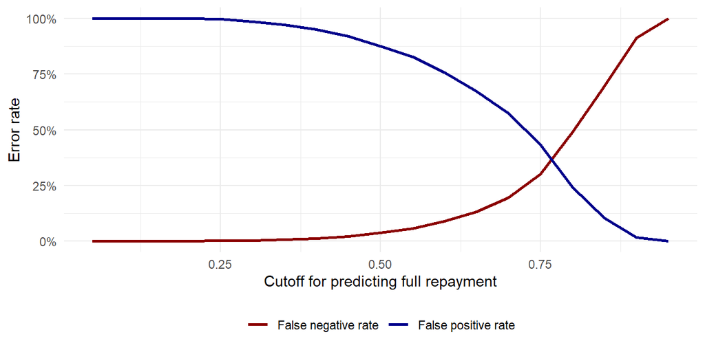

Changing the cutoff changes which mistakes the model makes.

## Defaults are expensive!

- A **false positive** can mean funding a loan that defaults.
- A **false negative** can mean declining a loan that would have repaid in full.
- A lender can choose a cutoff based on the relative costs of these errors, instead of choosing 0.5 automatically.
- Overall accuracy alone does not tell us which cutoff makes the best lending decision.